# w7a_lecture

Micaela Chapuis

2024-10-08

## Notes

**Some Helpful Packages**  
(other than ‘maps’, ‘mapproj’ and ‘mapdata’)  
- sf (This is for the serious GIS people. If you want to do actual spatial analyses this is the package to use)  
- ggmap (Uses the google maps API to make maps. Really easy to use, but requires a credit card for the API…)  
- tmap (static and interactive maps)  
- leaflet (interactive html maps– Awesome to use with rmakrdown files)

## Code

### Loading Libraries

```r
library(tidyverse)
library(here)
```

```r
library(maps)
library(mapproj)
library(mapdata)
```

### Loading in data

```r
# Read in data on population in California by county
popdata<-read_csv(here("Week7","Data","CApopdata.csv"))
#read in data on number of seastars at different field sites
stars<-read_csv(here("Week7","Data","stars.csv"))
```

### ‘Maps’ Package

The {maps} package is a combination of functions that pair well with ggplot and base layers for maps (i.e. polygons of regions of interest).  
- map_data(“location”) is the function used to pull out whatever base layer that you want

This package doesn’t get updated often so shouldn’t be used for cases when limits really matter.  
It’s also US centric, so we can only look at states, counties, etc for the US.  
Also this data is very coarse, so for really small islands (like Mo’orea in the world map) it will give a square-ish polygon.

We can extract polygons for different countries:  
- Entire world:

```r
world <- map_data("world") # get data for the entire world
head(world)
```

```
##        long      lat group order region subregion
## 1 -69.89912 12.45200     1     1  Aruba      <NA>
## 2 -69.89571 12.42300     1     2  Aruba      <NA>
## 3 -69.94219 12.43853     1     3  Aruba      <NA>
## 4 -70.00415 12.50049     1     4  Aruba      <NA>
## 5 -70.06612 12.54697     1     5  Aruba      <NA>
## 6 -70.05088 12.59707     1     6  Aruba      <NA>
```

- USA (Hawaii is left out):

```r
usa <- map_data("usa")
head(usa)
```

```
##        long      lat group order region subregion
## 1 -101.4078 29.74224     1     1   main      <NA>
## 2 -101.3906 29.74224     1     2   main      <NA>
## 3 -101.3620 29.65056     1     3   main      <NA>
## 4 -101.3505 29.63911     1     4   main      <NA>
## 5 -101.3219 29.63338     1     5   main      <NA>
## 6 -101.3047 29.64484     1     6   main      <NA>
```

We can also extract data at different resolutions. For example, US states:

```r
states <- map_data("state")
head(states)
```

```
##        long      lat group order  region subregion
## 1 -87.46201 30.38968     1     1 alabama      <NA>
## 2 -87.48493 30.37249     1     2 alabama      <NA>
## 3 -87.52503 30.37249     1     3 alabama      <NA>
## 4 -87.53076 30.33239     1     4 alabama      <NA>
## 5 -87.57087 30.32665     1     5 alabama      <NA>
## 6 -87.58806 30.32665     1     6 alabama      <NA>
```

```r
counties <- map_data("county")
head(counties)
```

```
##        long      lat group order  region subregion
## 1 -86.50517 32.34920     1     1 alabama   autauga
## 2 -86.53382 32.35493     1     2 alabama   autauga
## 3 -86.54527 32.36639     1     3 alabama   autauga
## 4 -86.55673 32.37785     1     4 alabama   autauga
## 5 -86.57966 32.38357     1     5 alabama   autauga
## 6 -86.59111 32.37785     1     6 alabama   autauga
```

#### Data Structure

- **long** is longitude. Things to the west of the prime meridian are negative.
- **lat** is latitude.
- **order**. This just shows in which order ggplot should “connect the dots”
- **region and subregion** tell what region or subregion a set of points surrounds.
- **group.** This is very important! ggplot2’s functions can take a group argument which controls (amongst other things) whether adjacent points should be connected by lines. If they are in the same group, then they get connected, but if they are in different groups then they don’t. Essentially, having to points in different groups means that ggplot “lifts the pen” when going between them.

#### Making a map of the world

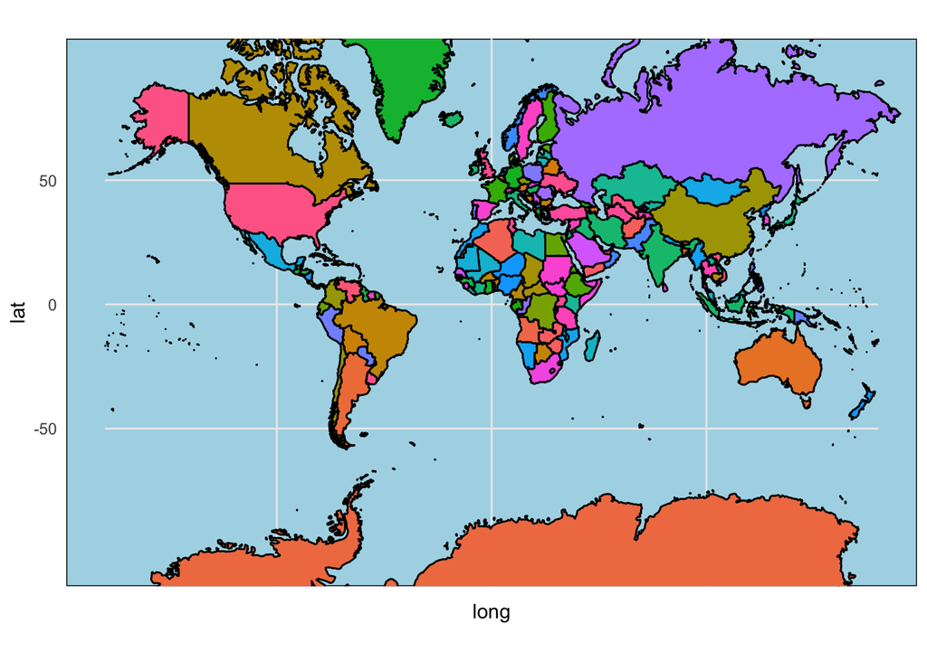

```r
ggplot() +
  geom_polygon(data = world,
               aes(x = long,
                   y = lat,
                   group = group,
                   fill = region), # fill by country
               color = "black") + # add color to the lines and fill
  guides(fill = FALSE) + # don't want the legend
  theme_minimal() +
  theme(panel.background = element_rect(fill = "lightblue")) +
  coord_map(projection = "mercator", # specify that we want to use the Mercator projection
            xlim = c(-180,180)) # set x limits
```

Alternative projection

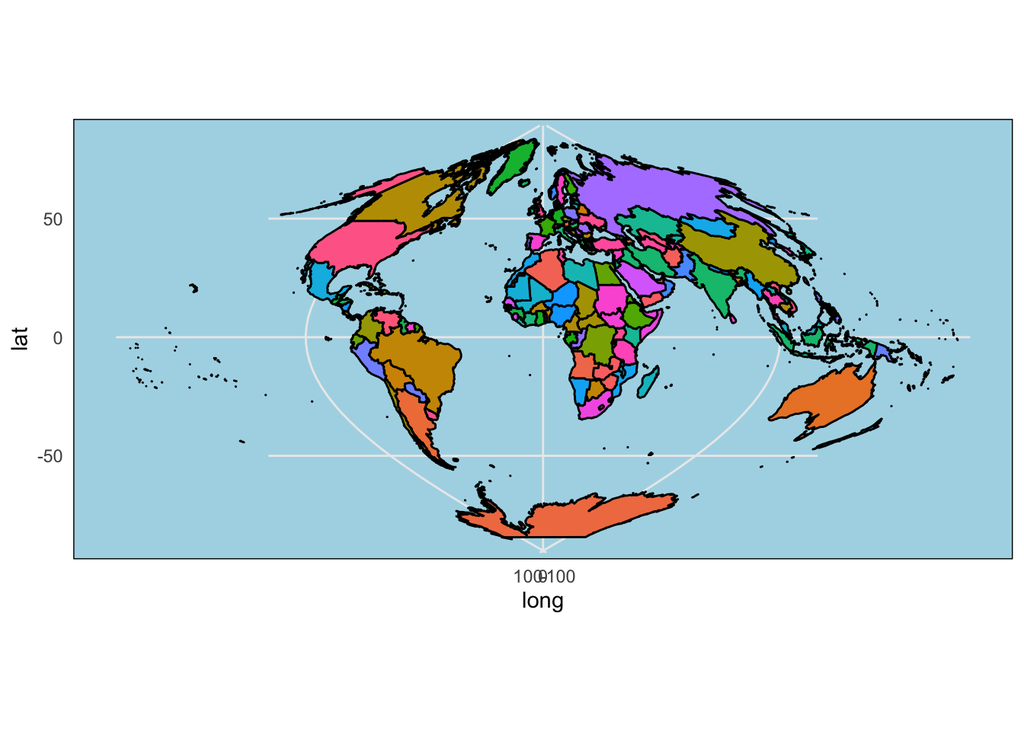

```r
ggplot() +
  geom_polygon(data = world,
               aes(x = long,
                   y = lat,
                   group = group,
                   fill = region), # fill by country
               color = "black") + # add color to the lines and fill
  guides(fill = FALSE) + # don't want the legend
  theme_minimal() +
  theme(panel.background = element_rect(fill = "lightblue")) +
  coord_map(projection = "sinusoidal", # specify that we want to use the sinusoidal projection
            xlim = c(-180,180)) # set x limits
```

#### Making a map of California

```r
# use the states dataset
head(states)
```

```
##        long      lat group order  region subregion
## 1 -87.46201 30.38968     1     1 alabama      <NA>
## 2 -87.48493 30.37249     1     2 alabama      <NA>
## 3 -87.52503 30.37249     1     3 alabama      <NA>
## 4 -87.53076 30.33239     1     4 alabama      <NA>
## 5 -87.57087 30.32665     1     5 alabama      <NA>
## 6 -87.58806 30.32665     1     6 alabama      <NA>
```

Filter out just the California data

```r
CA_data<-states %>%
  filter(region == "california")

head(CA_data)
```

```
##        long      lat group order     region subregion
## 1 -120.0060 42.00927     4   667 california      <NA>
## 2 -120.0060 41.20139     4   668 california      <NA>
## 3 -120.0060 39.70024     4   669 california      <NA>
## 4 -119.9946 39.44241     4   670 california      <NA>
## 5 -120.0060 39.31636     4   671 california      <NA>
## 6 -120.0060 39.16166     4   672 california      <NA>
```

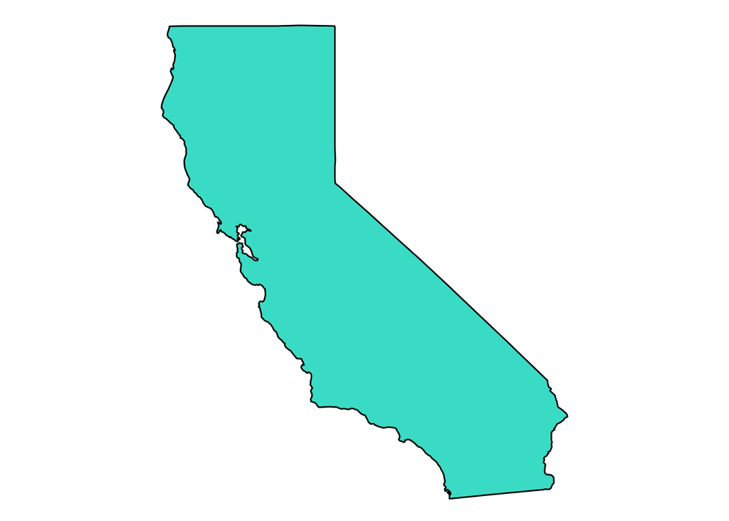

```r
ggplot() +
  geom_polygon(data = CA_data,
               aes(x = long,
                   y = lat,
                   group = group),
               color = "black", # add color to the lines
               fill = "turquoise") +
  theme_void() +  # can remove all the axis (lat/long)
  coord_map() # default is Mercator
```

### Adding population density data!

```r
# Look at the county data we got earlier
head(counties)[1:3,] # only showing the first 3 rows for space
```

```
##        long      lat group order  region subregion
## 1 -86.50517 32.34920     1     1 alabama   autauga
## 2 -86.53382 32.35493     1     2 alabama   autauga
## 3 -86.54527 32.36639     1     3 alabama   autauga
```

```r
# Look at county data
head(popdata)
```

```
## # A tibble: 6 × 2
##   County         Population
##   <chr>               <dbl>
## 1 los angeles      10081570
## 2 san diego         3316073
## 3 orange            3168044
## 4 riverside         2411439
## 5 san bernardino    2149031
## 6 santa clara       1927470
```

```r
CApop_county<-popdata %>%
  select("subregion" = County, Population)  %>% # rename the county column
  inner_join(counties) %>% # join with counties
  filter(region == "california") # some counties have same names in other states so only keep california
head(CApop_county)
```

```
## # A tibble: 6 × 7
##   subregion   Population  long   lat group order region
##   <chr>            <dbl> <dbl> <dbl> <dbl> <int> <chr>
## 1 los angeles   10081570 -119.  34.8   175  7827 california
## 2 los angeles   10081570 -118.  34.8   175  7828 california
## 3 los angeles   10081570 -118.  34.8   175  7829 california
## 4 los angeles   10081570 -118.  34.6   175  7830 california
## 5 los angeles   10081570 -118.  34.6   175  7831 california
## 6 los angeles   10081570 -118.  34.5   175  7832 california
```

#### Map of CA population by county

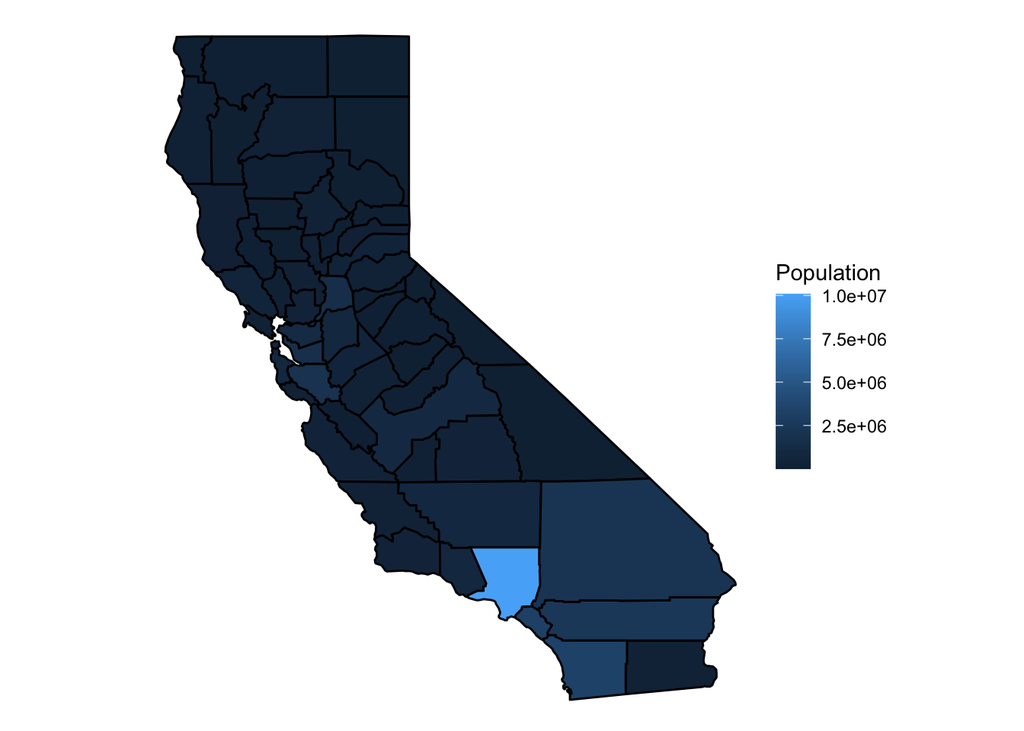

```r
ggplot() +
  geom_polygon(data = CApop_county,
               aes(x = long,
                   y = lat,
                   group=group,
                   fill = Population),
               color = "black") +
  coord_map() +
  theme_void()
```

But LA has soo many people that it looks low pop everywhere else, so we make it log scale for easier interpretation

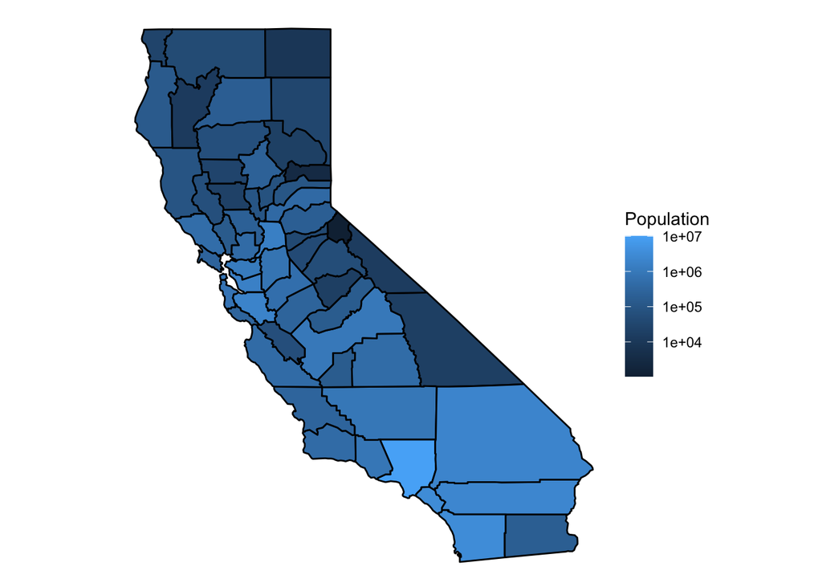

```r
ggplot()+
geom_polygon(data = CApop_county,
             aes(x = long,
                 y = lat,
                 group = group,
                 fill = Population),
             color = "black")+
  coord_map()+
  theme_void() +
  scale_fill_gradient(trans = "log10") # log transform data
```

### Adding Stars Data

The stars dataset has the number of seastars per/m2 at different sites in California.

```r
head(stars)
```

```
## # A tibble: 6 × 3
##     lat  long star_no
##   <dbl> <dbl>   <dbl>
## 1  33.5 -118.      10
## 2  35.5 -121.       1
## 3  39.5 -124.      25
## 4  32.9 -117.      22
## 5  33.5 -118.       8
## 6  33.5 -118.       3
```

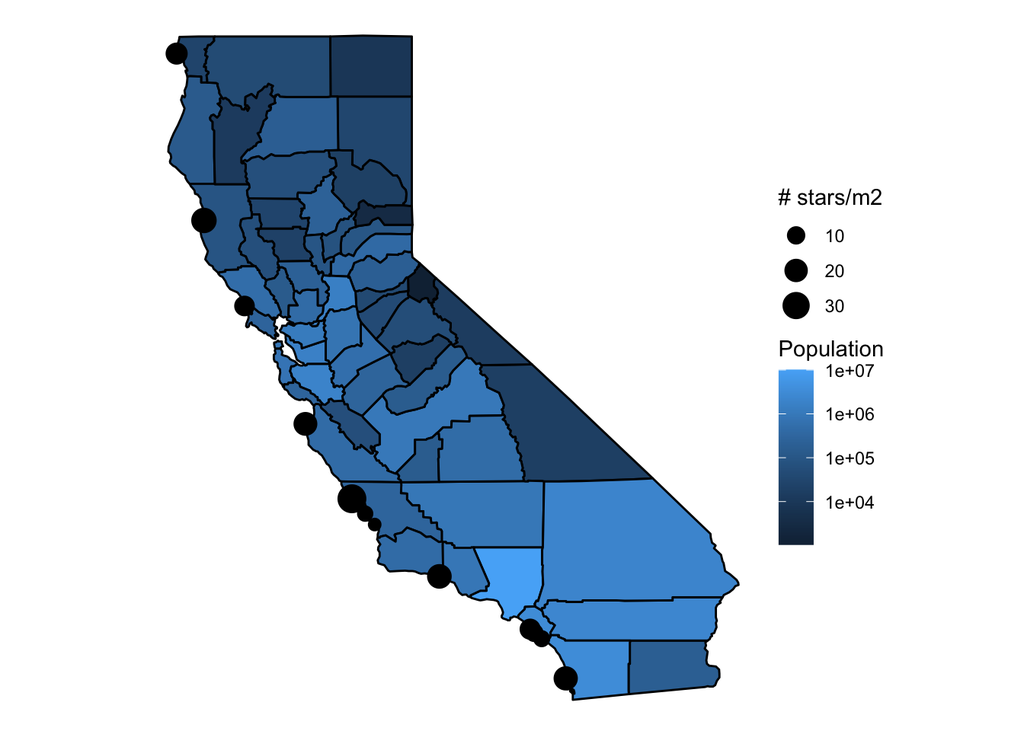

```r
ggplot()+
geom_polygon(data = CApop_county,
             aes(x = long,
                 y = lat,
                 group = group,
                 fill = Population),
             color = "black")+
  geom_point(data = stars, # add a point at all my sites of star counts
             aes(x = long,
                 y = lat,
                 size = star_no)) + # change the point size by number of stars
  coord_map()+
  theme_void() +
  scale_fill_gradient(trans = "log10") +
  labs(size = "# stars/m2")
```

```r
ggsave(here("Week7","Output","Homework", "CApop.pdf"))
```